# MAPPD report

DSR Sequencing Laboratory

14 September, 2023

setwd(“/datasets/work/aahl-pdngs/work/test_data/evag2/2.mappd”)

overall_figure = “logs/overall_results.png” config_file = “config.yaml” dag = “benchmarks/dag.png” bench_time = “benchmarks/bench_time.png” bench_mem = “benchmarks/bench_mem.png”

## Technical Summary

MAPPD is a general pipeline for the identification of organisms in a metagenomic sample, although it is targeted toward the identification of pathogens. The pipeline uses a strategy of read quality trimming, host identification, read assembly, and annotation using various blast and diamond searches. MAPPD does not require prior information about the sample (e.g. host), as this information is determined by classifying read sub-sets.

### Important

Metagenomic analysis can be a useful technology for screening samples in cases where a pathogen is unknown. However, the classication of sequence fragments based on the highest identity in a database does not necessarily mean that a pathogen is present, only that this is the ‘best’ match. This report provides the percent identity of database hits and the location of the particular contigs. It is necessary to check important classifications manually. Additional laboratory tests are required to confirm pathogen identification.

## Overall Classifications

### Data Quality and Overall Classifications

The raw data were trimmed for quality and adapters using Trimmomatic. The cleaned reads were then aligned to the SILVA ribosomal RNA databases, including the Long Sub Unit (LSU) and Small Sub Unit (SSU) categories, and matching reads were removed.

The remaining reads were then classified using iterative assemblies, blasts and diamond searches. Reads that could not be classified after these processes are shown as the grey ‘Unannotated’ bar below.

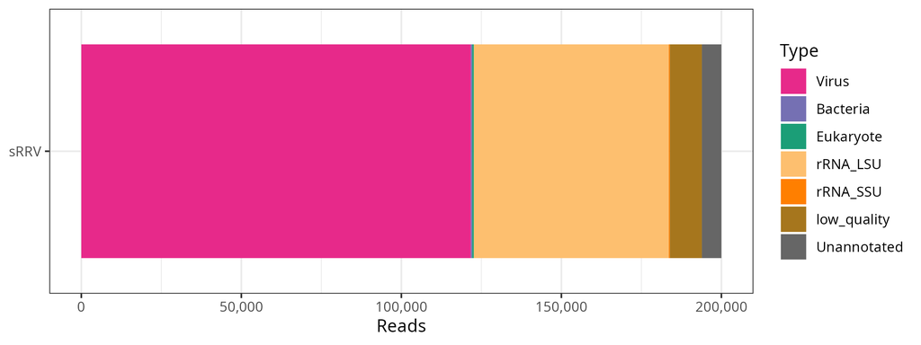

[figure not shown]